# Natalie Karavarsamis, PhD

09 May, 2019

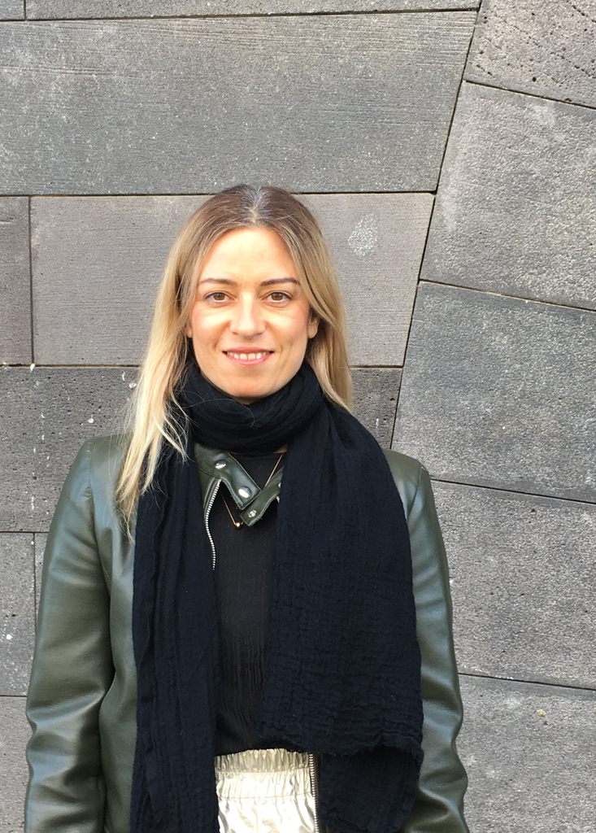

**Dr Natalie Karavarsamis**

Lecturer  
Department of Mathematics and Statistics  
La Trobe University  
Melbourne, Victoria, Australia  
Email: n.karavarsamis@latrobe.edu.au

Honorary Fellow  
School of Mathematics and Statistics  
University of Melbourne  
Victoria, Australia  
Email: nkarav@unimelb.edu.au

Technical sub-editor at the Australian and New Zealand Journal of Statistics and reviewer to several journals.

**Announcements**

**2019**

- **Registration and submissions now open** for Workshop for Research School on Statistics and Data Science 2019 (RSSDS2019), La Trobe, Melbourne, Australia. Topics include Statistics, Data Science and allied fields such as AI and Machine Learning are invited to register. Deadline for abstract submissions before **31st May, 2019**. Workshop proceedings published in **Springer Communications in Computer and Information Science (CCIS)** volume. [Webpage](https://sites.google.com/view/rssds2019/home) and poster.

**Events**

**2019**

- May 15, **Q&A panel discussion speaker** for celebrations of the first International Women in Mathematics Day, on 12 May in honour of the birthday of Maryam Mirzakhani, the first female Fields Medalist (the analogue of the Nobel Prize for mathematicians), poster.
- June 5, Speaker Joint Seminar, La Trobe University & Harvard University, La Trobe University.
- June 19, Invited Speaker, Choose Maths Day, La Trobe University.
- June 25-27, **EcoSta2019** Conference presentation. National Chung Hsing University, Taiwan. [Conference Webpage](http://cmstatistics.org/EcoSta2019/index.php).
- July 24–26, **Invited Speaker**, Workshop for Research School on Statistics and Data Science 2019 (RSSDS2019), La Trobe, Melbourne, Australia. [Webpage](https://sites.google.com/view/rssds2019/home) and poster.

**Bio**

I am Lecturer in Statistics at La Trobe University. I obtained my PhD in Statistics from the Department of Mathematics and Statistics, University of Melbourne. I have prfessional statististician industry consulting experience prior to my academic career at several institutions, for example Cancer Council of Victoria, Department of Primary Industries, School of Medicine (University of Crete, Greece). Academic posts include Lecturer at School of Mathematics and Statistics (University of Melbourne), Postdoctoral Research Fellow with School of Biosciences (University of Melbourne) and with School of Mathmeatical Sciences (RMIT), and Research Fellow at Department of Food and Land Sciences (prior to PhD) (University of Melbourne). Current roles include Techincail Sub-Editor to the Australian and New Zealand Journal of Statistics, and serve as reviewer for internationl journals.

Research collaborations include Harvard University (USA), University of Caen (France), La Trobe University (Australia) and University of Melbourne (Australia). Research interests include ecological statistics, analysis and modelling of large biological data and medical statistics. Modern statistical approaches for occupancy using partial, conditional and composite likelihoods, and with GAMs. R software is available for selected methods. Analysis and development of models for large time-series biological data, functional analysis, HMMs and models for cylindrical distributions. With applications in neuroscience in collaboration with Harvard University.

See details in my CV.

**Supervision**

Available for Honours, Masters and PhD.  
* PhD Statistics - Co-supervisor (2018–)  
* Master of Statistics - Supervisor (2019)  
* AMSI Summer Scholars - Supervisor, two scholars (2019)

**Grants & Awards** (selected)

2016– Early Researcher Establishment Grant, School of Mathematics and Statistics, University of Melbourne.

2018 Australian-French Association for Research and Innovation (AFRAN).

**Press & Gallery**

2018 AMSI Choose Maths Day, La Trobe